# Demonstration Beamer/Reveal

Igor M. Coelho

April 8, 2020

# Part 1: Basics

## Basic Formatting

Text formatting requires a few things, such as lists (prefix `-`, `*` or `+`):

- **bold** (Markdown `**bold**`, LaTeX `\textbf{bold}`)
- *italics* (Markdown `*italics*`, LaTeX `\textit{italics}`)
  - *bold and italics* (Markdown `***` symbol, LaTeX `\textbf{\textit{...}}`)

Enumeration lists can use `1.` or `#.` prefix:

1. one
2. two

### An important reminder for $\text{\LaTeX}$

Use math mode as `$\sum_{i=0}^{n}\sqrt{i}$` for $\sum_{i=0}^{n}\sqrt{i}$.

For color use “`--filter pandoc-latex-color`”: then use `<span latex-color="green" style="color:green;">abc</span>`.

## Headers and Tables

Headers can become different things (e.g,`--slide-level 2` on Pandoc):

| Slide | Header 1 (`#`) | Header 2 (`##`) | Header 3 (`###`) |
| --- | --- | --- | --- |
| Level 1 | Frame | Box |  |
| Level 2 | Section | Frame | Box |
| Level 3 | ^ | Subsection | Frame |

You just need to use standard markdown table notation:

```
| Slide   | Header 1 (`#`) | Header 2 (`##`) | Header 3 (`###`) |
| :---    |    :----       |         :---:   |          ---:    |
| Level 1 | Frame          | Box                               ||
| Level 2 | Section        | Frame           | Box              |
| Level 3 | ^              | Subsection      | Frame            |
```

## Images

We saw basic formatting. To insert figures, use Markdown notation: `![AltText](./filename.jpg "Title")`

To resize it and visualize on Atom, Beamer and Reveal, just use Pandoc `bracketed_spans` notation: `{width=80%}`.

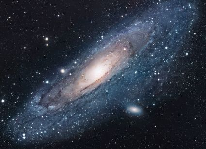

An universe picture

Example: `![An universe picture](./universe.jpg "An example image"){width=40%}`

## Organization and Columns (Part I)

Let’s divide in three parts (35%, 30%, 35%):

- First column
  - Some item

**Just an equation:**
$$\sum_{i=0}^{n}\sqrt{i}$$

1. A third column
   - Something
2. One extra item

*To create multiple columns in a compatible way, we can use:*

```html
<div class="columns">
  <div class="column" width="35%" style="max-width:35%;">
     Content for column with 35% size
  </div>
</div>
```

## Fenced Divs

This code should allow organizing text into column.

*Single centered column*

```
::::::::::::: {.columns}
::::: {.column width=100%}
::: {.centered}
\centering
*Single centered column*
:::
:::::
:::::::::::::
```

This doesn’t work on Typora or Atom, but works on LaTeX and Reveal.

For centering, just `::: {.centered}` and `\centering` would be enough.

## Organization and Columns (Part II)

Double column with image on side (20% and 80%):

- One topic
  - Another item
- Second topic
  - One extra
    - One deeper level

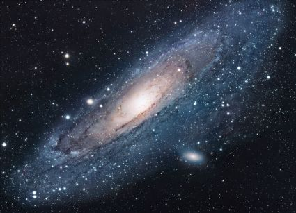

An universe picture

### Fenced Divs

Note that Pandoc 2.9 provides a special syntax for fenced divs, like: `::::::: {.columns}` and `::: {.column width="50%"}`. This is not recommended because Atom Preview will not understand it. For the same reason, use both `max-width=50%;` and `width="50%"`.

## Some notes

This slide will only ask you to press `s` on Reveal. This will put you on `Speaker Mode` and you’ll see the notes.

### For Beamer

This is more complicated, but possible. It requires an specialized `pdf` player for multiple monitors, like `pdfpc` or `pympress`.

```
%\documentclass[notes]{beamer}       % frame + notes
\documentclass[notes=only]{beamer}   % only notes
%\documentclass{beamer}              % only frames
```

# Thanks

## Last advices

Never add frame breaks `------` before Level 1 headers (`#`). Otherwise it will create a blank slide ;)

#### Practice on Atom, VSCode or Typora editors

On Atom, install one of these plugins:

- Markdown Preview Plus: `https://atom.io/packages/markdown-preview-plus`
- Markdown Preview Enhanced: `https://atom.io/packages/markdown-preview-enhanced`

Comparison on syntax for Markdown-It and Pandoc: see [Atom community discussion](https://github.com/atom-community/markdown-preview-plus/wiki/markdown-it-vs.-pandoc).

See more reveal.js themes on `https://github.com/hakimel/reveal.js`

*See you next time!*